# Practical 7 - Introduction to ML

This week, we are kicking off a new topic: Machine Learning (ML). We will start by covering the fundamental concepts of ML and building some ML models to tackle a simple yet classic problem.

### Import necessary libraries

```python
import pandas as pd              # Used for data manipulation and analysis
import numpy as np               # Used for numerical operations and arrays
import matplotlib.pyplot as plt  # Import the matplotlib library's pyplot module for plotting data visualizations
import seaborn as sns            # Import the seaborn library for advanced data visualization
```

### Import specific modules from scikit-learn for model creation and evaluation

```python
from sklearn.model_selection import train_test_split               # Used to split data into training and testing sets
from sklearn.preprocessing import LabelEncoder                     # Used to convert categorical data into numerical format
from sklearn.preprocessing import MinMaxScaler                     # Used to normalize the data
from sklearn.tree import DecisionTreeClassifier                    # Decision Tree model for classification
from sklearn.ensemble import RandomForestClassifier                # RandomForestClassifier from the sklearn.ensemble module
from sklearn.svm import SVC                                        # SVC for classification
from sklearn.naive_bayes import GaussianNB                         # Import the Gaussian Naive Bayes classifier from Scikit-Learn
from sklearn.neighbors import KNeighborsClassifier                 # Import the K-Nearest Neighbors classifier from Scikit-Learn
from sklearn.metrics import accuracy_score, classification_report  # Metrics to evaluate model performance
from sklearn.metrics import ConfusionMatrixDisplay                 # used to display confusion matrix
```

# Data Overview

The dataset provides information about passengers on the Titanic, including details such as age, gender, class, and survival status. It serves as a foundation for analyzing factors that might have influenced survival outcomes.

### Load and display the Titanic dataset into a pandas DataFrame

```python
data = pd.read_csv('titanic.csv')            # Load the Titanic dataset
data.head(10)                                # Display the first 10 entries in the dataset to understand its structure
```

|  | PassengerId | Survived | Pclass | Name | Sex | Age | SibSp | Parch | Ticket | Fare | Cabin | Embarked |
| --- | --- | --- | --- | --- | --- | --- | --- | --- | --- | --- | --- | --- |
| 0 | 1 | 0 | 3 | Braund, Mr. Owen Harris | male | 22.0 | 1 | 0 | A/5 21171 | 7.2500 | NaN | S |
| 1 | 2 | 1 | 1 | Cumings, Mrs. John Bradley (Florence Briggs Th... | female | 38.0 | 1 | 0 | PC 17599 | 71.2833 | C85 | C |
| 2 | 3 | 1 | 3 | Heikkinen, Miss. Laina | female | 26.0 | 0 | 0 | STON/O2. 3101282 | 7.9250 | NaN | S |
| 3 | 4 | 1 | 1 | Futrelle, Mrs. Jacques Heath (Lily May Peel) | female | 35.0 | 1 | 0 | 113803 | 53.1000 | C123 | S |
| 4 | 5 | 0 | 3 | Allen, Mr. William Henry | male | 35.0 | 0 | 0 | 373450 | 8.0500 | NaN | S |
| 5 | 6 | 0 | 3 | Moran, Mr. James | male | NaN | 0 | 0 | 330877 | 8.4583 | NaN | Q |
| 6 | 7 | 0 | 1 | McCarthy, Mr. Timothy J | male | 54.0 | 0 | 0 | 17463 | 51.8625 | E46 | S |
| 7 | 8 | 0 | 3 | Palsson, Master. Gosta Leonard | male | 2.0 | 3 | 1 | 349909 | 21.0750 | NaN | S |
| 8 | 9 | 1 | 3 | Johnson, Mrs. Oscar W (Elisabeth Vilhelmina Berg) | female | 27.0 | 0 | 2 | 347742 | 11.1333 | NaN | S |
| 9 | 10 | 1 | 2 | Nasser, Mrs. Nicholas (Adele Achem) | female | 14.0 | 1 | 0 | 237736 | 30.0708 | NaN | C |

### Print the shape of the dataset to understand its dimensions (rows, columns)

```python
print(data.shape)   #Print the shape
```

```
(891, 12)
```

### Display a concise summary of the DataFrame

```python
data.info()
```

```
<class 'pandas.core.frame.DataFrame'>
RangeIndex: 891 entries, 0 to 890
Data columns (total 12 columns):
 #   Column       Non-Null Count  Dtype
---  ------       --------------  -----
 0   PassengerId  891 non-null    int64
 1   Survived     891 non-null    int64
 2   Pclass       891 non-null    int64
 3   Name         891 non-null    object
 4   Sex          891 non-null    object
 5   Age          714 non-null    float64
 6   SibSp        891 non-null    int64
 7   Parch        891 non-null    int64
 8   Ticket       891 non-null    object
 9   Fare         891 non-null    float64
 10  Cabin        204 non-null    object
 11  Embarked     889 non-null    object
dtypes: float64(2), int64(5), object(5)
memory usage: 83.7+ KB
```

### Print a list of column names in the dataset to understand the available features

```python
print(list(data.columns))    # Print a list of column names
```

```
['PassengerId', 'Survived', 'Pclass', 'Name', 'Sex', 'Age', 'SibSp', 'Parch', 'Ticket', 'Fare', 'Cabin', 'Embarked']
```

### Calculate the total number of missing values in each column of the dataset

```python
missing_values = data.isnull().sum()   # Calculate the total number of missing values
print(missing_values)                  # Print the number of missing values for each column to identify data completeness issues
```

```
PassengerId      0
Survived         0
Pclass           0
Name             0
Sex              0
Age            177
SibSp            0
Parch            0
Ticket           0
Fare             0
Cabin          687
Embarked         2
dtype: int64
```

### Plotting missing values in each column as a bar graph

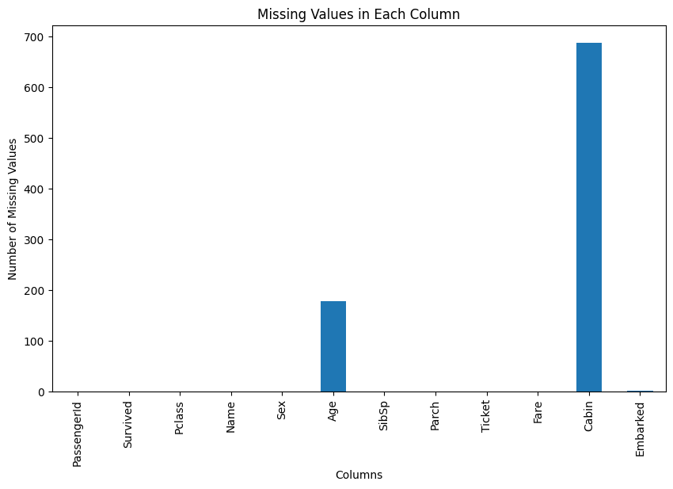

```python
plt.figure(figsize=(10, 6))
missing_values.plot(kind='bar')
plt.title('Missing Values in Each Column')
plt.xlabel('Columns')
plt.ylabel('Number of Missing Values')
plt.show()
```

### Define a function to create a stacked bar chart for a given feature

```python
def bar_chart(feature):
    survived = data[data['Survived'] == 1][feature].value_counts()     # Count the occurrences of each category for the chosen feature where passengers survived
    dead = data[data['Survived'] == 0][feature].value_counts()         # Count the occurrences of each category for the chosen feature where passengers did not survive
    df = pd.DataFrame([survived, dead])                                # Create a DataFrame combining the counts of survived and dead passengers for the feature
    df.index = ['Survived', 'Dead']                                    # Set custom index labels for the rows to indicate survival status
    df.plot(kind='bar', stacked=True, figsize=(10, 5))                  # Plot a stacked bar chart to show the relationship between survival status and the feature
```

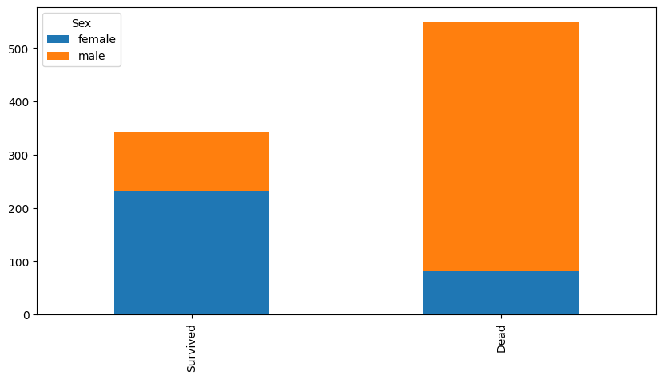

```python
bar_chart('Sex')     # Generate a bar chart to visualize survival rates based on the 'Sex' feature
```

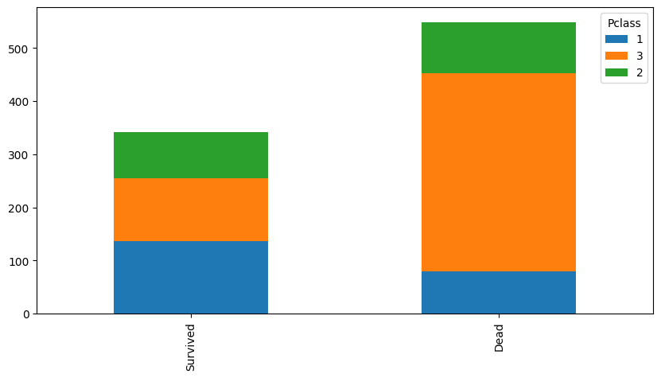

```python
bar_chart('Pclass') # Generate a bar chart to visualize survival rates based on the 'Pclass' feature
```

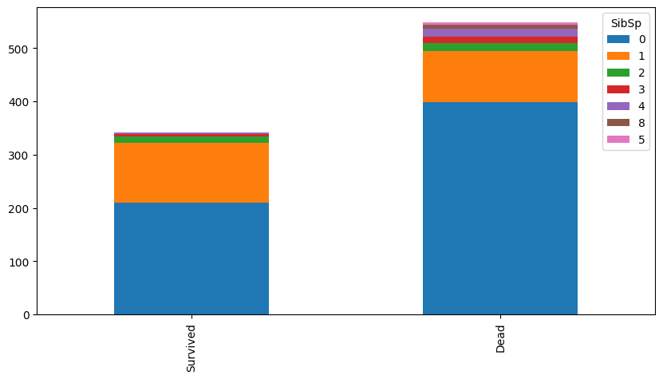

```python
bar_chart('SibSp')  # Generate a bar chart to visualize survival rates based on the 'SibSp' feature
```

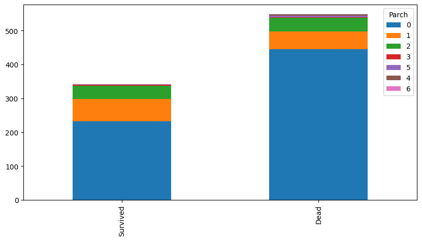

```python
bar_chart('Parch')   # Generate a bar chart to visualize survival rates based on the 'Parch' feature
```

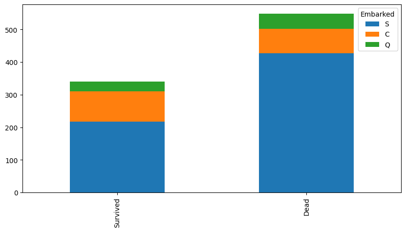

```python
bar_chart('Embarked')    # Generate a bar chart to visualize survival rates based on the 'Embarked' feature
```

### Extract the title from each passenger's name in the single DataFrame

```python
data['Title'] = data['Name'].str.extract(r' ([A-Za-z]+)\.', expand=False)

title_counts = data['Title'].value_counts()  # Count of each title to understand the distribution of titles in the dataset
print(title_counts)
```

```
Title
Mr          517
Miss        182
Mrs         125
Master       40
Dr            7
Rev           6
Mlle          2
Major         2
Col           2
Countess      1
Capt          1
Ms            1
Sir           1
Lady          1
Mme           1
Don           1
Jonkheer      1
Name: count, dtype: int64
```

### Plotting a bar graph of title counts

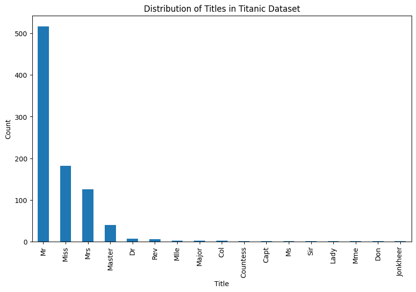

```python
plt.figure(figsize=(10, 6))
title_counts.plot(kind='bar')
plt.title('Distribution of Titles in Titanic Dataset')
plt.xlabel('Title')
plt.ylabel('Count')
plt.show()
```

### Create a FacetGrid to plot the kernel density estimate (KDE) of the 'Age' feature by survival status

This visualization helps compare the age distributions of passengers who survived and those who did not. By narrowing the x-axis, it highlights patterns in younger age ranges, which can be useful in analyzing survival trends by age.

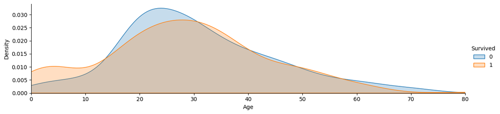

```python
facet = sns.FacetGrid(data, hue="Survived", aspect=4)   # Create a FacetGrid to plot the KDE of the 'Age' feature by survival status

facet.map(sns.kdeplot, 'Age', fill=True)               # Plot KDE for the 'Age' feature with filled area to show density, separated by survival status
facet.set(xlim=(0, data['Age'].max()))                 # Set the x-axis limit to range from 0 to the maximum age in the dataset
facet.add_legend()                                     # Add a legend to differentiate survival categories in the plot
plt.show()                                             # Display the plot
```

```
(0.0, 20.0)
```

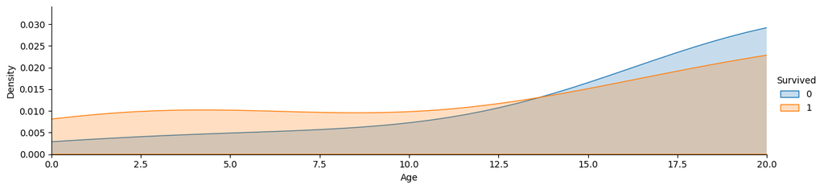

```python
facet = sns.FacetGrid(data, hue="Survived", aspect=4)

facet.map(sns.kdeplot, 'Age', fill=True) # Plot KDE for the 'Age' feature with fill to show density, separated by survival status
facet.set(xlim=(0, data['Age'].max()))   # Set the x-axis limit to range from 0 to the maximum age in the dataset
facet.add_legend()                       # Add a legend to identify each survival category in the plot
plt.xlim(0, 20)                          # Further limit the x-axis to 0–20 to focus on the age range of younger passengers
```

### Create a FacetGrid to plot the KDE of the 'Fare' feature by survival status

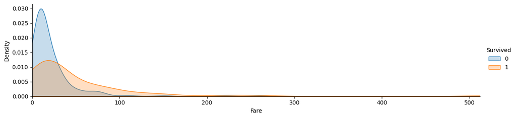

```python
facet = sns.FacetGrid(data, hue="Survived", aspect=4)

facet.map(sns.kdeplot, 'Fare', fill=True)        # Plot KDE for the 'Fare' feature with filled area to show density, separated by survival status
facet.set(xlim=(0, data['Fare'].max()))         # Set the x-axis limit to range from 0 to the maximum fare in the dataset
facet.add_legend()                              # Add a legend to differentiate survival categories in the plot
plt.show()                                     # Display the plot
```

```
(0.0, 20.0)
```

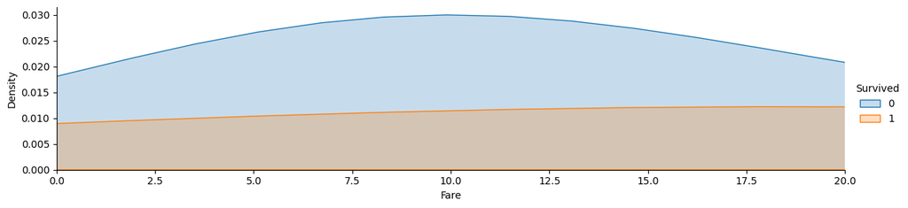

```python
facet = sns.FacetGrid(data, hue="Survived", aspect=4)

facet.map(sns.kdeplot, 'Fare', fill=True)        # Plot KDE for the 'Fare' feature with filled area to show density, separated by survival status
facet.set(xlim=(0, data['Fare'].max()))         # Set the x-axis limit to range from 0 to the maximum fare in the dataset
facet.add_legend()                              # Add a legend to differentiate survival categories in the plot
plt.xlim(0, 20)
```

### Create a FacetGrid to plot the KDE of the 'FamilySize' feature by survival status

```python
# Create a new feature 'FamilySize' by adding the number of siblings/spouses ('SibSp')
# and the number of parents/children ('Parch') for each passenger, plus 1 (for the passenger themselves)
data["FamilySize"] = data["SibSp"] + data["Parch"] + 1
data
```

|  | PassengerId | Survived | Pclass | Name | Sex | Age | SibSp | Parch | Ticket | Fare | Cabin | Embarked | Title | FamilySize |
| --- | --- | --- | --- | --- | --- | --- | --- | --- | --- | --- | --- | --- | --- | --- |
| 0 | 1 | 0 | 3 | Braund, Mr. Owen Harris | male | 22.0 | 1 | 0 | A/5 21171 | 7.2500 | NaN | S | Mr | 2 |
| 1 | 2 | 1 | 1 | Cumings, Mrs. John Bradley (Florence Briggs Th... | female | 38.0 | 1 | 0 | PC 17599 | 71.2833 | C85 | C | Mrs | 2 |
| 2 | 3 | 1 | 3 | Heikkinen, Miss. Laina | female | 26.0 | 0 | 0 | STON/O2. 3101282 | 7.9250 | NaN | S | Miss | 1 |
| 3 | 4 | 1 | 1 | Futrelle, Mrs. Jacques Heath (Lily May Peel) | female | 35.0 | 1 | 0 | 113803 | 53.1000 | C123 | S | Mrs | 2 |
| 4 | 5 | 0 | 3 | Allen, Mr. William Henry | male | 35.0 | 0 | 0 | 373450 | 8.0500 | NaN | S | Mr | 1 |
| ... | ... | ... | ... | ... | ... | ... | ... | ... | ... | ... | ... | ... | ... | ... |
| 886 | 887 | 0 | 2 | Montvila, Rev. Juozas | male | 27.0 | 0 | 0 | 211536 | 13.0000 | NaN | S | Rev | 1 |
| 887 | 888 | 1 | 1 | Graham, Miss. Margaret Edith | female | 19.0 | 0 | 0 | 112053 | 30.0000 | B42 | S | Miss | 1 |
| 888 | 889 | 0 | 3 | Johnston, Miss. Catherine Helen "Carrie" | female | NaN | 1 | 2 | W./C. 6607 | 23.4500 | NaN | S | Miss | 4 |
| 889 | 890 | 1 | 1 | Behr, Mr. Karl Howell | male | 26.0 | 0 | 0 | 111369 | 30.0000 | C148 | C | Mr | 1 |
| 890 | 891 | 0 | 3 | Dooley, Mr. Patrick | male | 32.0 | 0 | 0 | 370376 | 7.7500 | NaN | Q | Mr | 1 |

891 rows × 14 columns

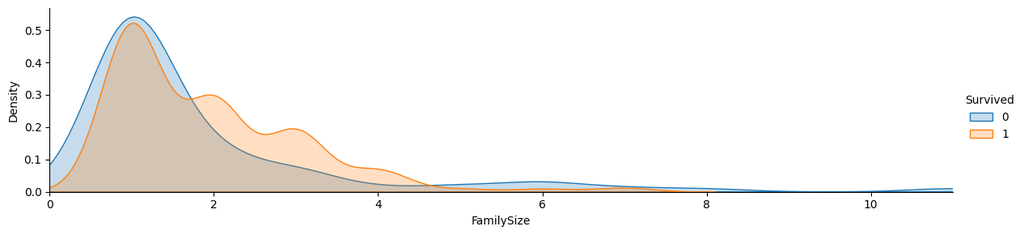

```python
facet = sns.FacetGrid(data, hue="Survived", aspect=4)

facet.map(sns.kdeplot, 'FamilySize', fill=True) # Plot KDE for the 'FamilySize' feature with filled area to show density, separated by survival status
facet.set(xlim=(0, data['FamilySize'].max()))  # Set the x-axis limit to range from 0 to the maximum family size in the dataset
facet.add_legend()                             # Add a legend to differentiate survival categories in the plot
plt.xlim(0)                                    # Set the x-axis limit to start at 0
plt.show()                                     # Display the plot
```

### Generating a sample correlation matrix (hypothetical data for demonstration purposes)

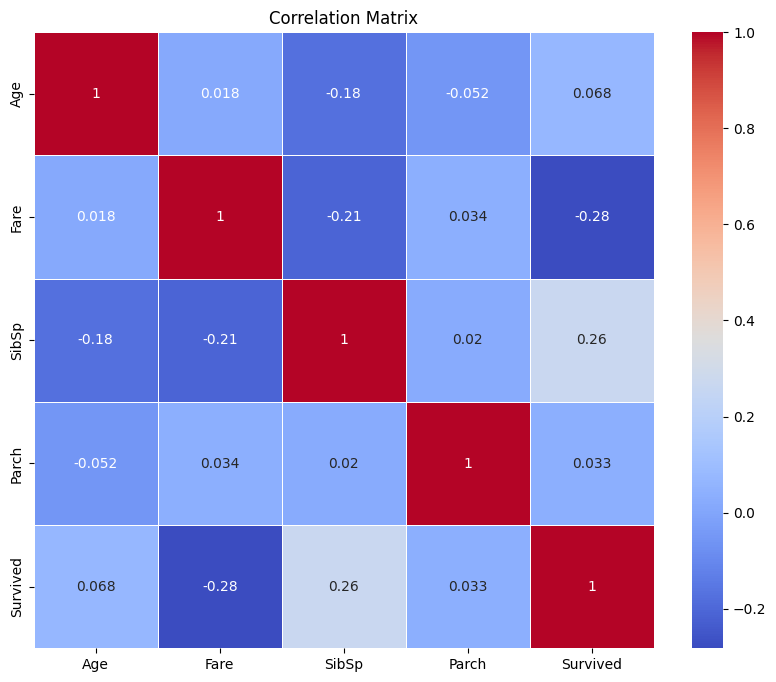

```python
np.random.seed(0)
sample_data = pd.DataFrame({
    'Age': np.random.randint(1, 80, 100),
    'Fare': np.random.randint(5, 100, 100),
    'SibSp': np.random.randint(0, 5, 100),
    'Parch': np.random.randint(0, 5, 100),
    'Survived': np.random.randint(0, 2, 100)
})

# Calculating the correlation matrix
correlation_matrix = sample_data.corr()

# Plotting the correlation matrix
plt.figure(figsize=(10, 8))
sns.heatmap(correlation_matrix, annot=True, cmap='coolwarm', linewidths=0.5)
plt.title('Correlation Matrix')
plt.show()
```

# Data Preprocessing

Data preprocessing involves cleaning and transforming the raw dataset to make it suitable for analysis. In the Titanic dataset, preprocessing steps typically include handling missing values, encoding categorical variables, and scaling numerical features. Missing values in columns such as "Age" and "Cabin" are often imputed or removed, while categorical columns like "Sex" and "Embarked" are converted into numerical representations. Additional feature engineering may be applied, such as extracting titles from names or combining family size information, to create meaningful predictors for model training.

```python
data['Age'] = data['Age'].fillna(data['Age'].median())  # This is useful for handling missing data while preserving central tendencies in the dataset
data.head(5)                                            # Display the modified dataset to confirm changes
```

|  | PassengerId | Survived | Pclass | Name | Sex | Age | SibSp | Parch | Ticket | Fare | Cabin | Embarked | Title | FamilySize |
| --- | --- | --- | --- | --- | --- | --- | --- | --- | --- | --- | --- | --- | --- | --- |
| 0 | 1 | 0 | 3 | Braund, Mr. Owen Harris | male | 22.0 | 1 | 0 | A/5 21171 | 7.2500 | NaN | S | Mr | 2 |
| 1 | 2 | 1 | 1 | Cumings, Mrs. John Bradley (Florence Briggs Th... | female | 38.0 | 1 | 0 | PC 17599 | 71.2833 | C85 | C | Mrs | 2 |
| 2 | 3 | 1 | 3 | Heikkinen, Miss. Laina | female | 26.0 | 0 | 0 | STON/O2. 3101282 | 7.9250 | NaN | S | Miss | 1 |
| 3 | 4 | 1 | 1 | Futrelle, Mrs. Jacques Heath (Lily May Peel) | female | 35.0 | 1 | 0 | 113803 | 53.1000 | C123 | S | Mrs | 2 |
| 4 | 5 | 0 | 3 | Allen, Mr. William Henry | male | 35.0 | 0 | 0 | 373450 | 8.0500 | NaN | S | Mr | 1 |

```python
missing_values = data.isnull().sum()   # Calculate the total number of missing values
print(missing_values)                  # Print the number of missing values for each column to identify data completeness issues
```

```
PassengerId      0
Survived         0
Pclass           0
Name             0
Sex              0
Age              0
SibSp            0
Parch            0
Ticket           0
Fare             0
Cabin          687
Embarked         2
Title            0
FamilySize       0
dtype: int64
```

### Drop the 'Cabin' column from the dataset as it has too many missing values

```python
data.drop(columns=['Cabin'], inplace=True)              # Dropping this column helps simplify the dataset without significantly impacting the analysis
data.head(5)                                            # Display the modified dataset to confirm changes
```

|  | PassengerId | Survived | Pclass | Name | Sex | Age | SibSp | Parch | Ticket | Fare | Embarked | Title | FamilySize |
| --- | --- | --- | --- | --- | --- | --- | --- | --- | --- | --- | --- | --- | --- |
| 0 | 1 | 0 | 3 | Braund, Mr. Owen Harris | male | 22.0 | 1 | 0 | A/5 21171 | 7.2500 | S | Mr | 2 |
| 1 | 2 | 1 | 1 | Cumings, Mrs. John Bradley (Florence Briggs Th... | female | 38.0 | 1 | 0 | PC 17599 | 71.2833 | C | Mrs | 2 |
| 2 | 3 | 1 | 3 | Heikkinen, Miss. Laina | female | 26.0 | 0 | 0 | STON/O2. 3101282 | 7.9250 | S | Miss | 1 |
| 3 | 4 | 1 | 1 | Futrelle, Mrs. Jacques Heath (Lily May Peel) | female | 35.0 | 1 | 0 | 113803 | 53.1000 | S | Mrs | 2 |
| 4 | 5 | 0 | 3 | Allen, Mr. William Henry | male | 35.0 | 0 | 0 | 373450 | 8.0500 | S | Mr | 1 |

### Drop 'PassengerId', 'Name', 'Title', and 'Ticket' columns as they are not essential for predictive analysis

```python
data.drop(columns=['PassengerId', 'Name', 'Ticket', 'Title'], inplace=True)  # 'PassengerId' is an identifier, and 'Name' and 'Ticket' don't directly contribute to survival prediction
data.head(5)                                                          # Display the first five rows of the updated dataset to confirm the changes
```

|  | Survived | Pclass | Sex | Age | SibSp | Parch | Fare | Embarked | FamilySize |
| --- | --- | --- | --- | --- | --- | --- | --- | --- | --- |
| 0 | 0 | 3 | male | 22.0 | 1 | 0 | 7.2500 | S | 2 |
| 1 | 1 | 1 | female | 38.0 | 1 | 0 | 71.2833 | C | 2 |
| 2 | 1 | 3 | female | 26.0 | 0 | 0 | 7.9250 | S | 1 |
| 3 | 1 | 1 | female | 35.0 | 1 | 0 | 53.1000 | S | 2 |
| 4 | 0 | 3 | male | 35.0 | 0 | 0 | 8.0500 | S | 1 |

### Define a mapping to categorize 'FamilySize' into specific scaled values

```python
# This mapping assigns a scaled score based on family size
family_mapping = {1: 0, 2: 0.4, 3: 0.8, 4: 1.2, 5: 1.6, 6: 2, 7: 2.4, 8: 2.8, 9: 3.2, 10: 3.6, 11: 4}

# Map the 'FamilySize' values in the data DataFrame to the scaled values specified in 'family_mapping'
data['FamilySize'] = data['FamilySize'].map(family_mapping)

# Display the first five rows to confirm the mapping
data.head(5)
```

|  | Survived | Pclass | Sex | Age | SibSp | Parch | Fare | Embarked | FamilySize |
| --- | --- | --- | --- | --- | --- | --- | --- | --- | --- |
| 0 | 0 | 3 | male | 22.0 | 1 | 0 | 7.2500 | S | 0.4 |
| 1 | 1 | 1 | female | 38.0 | 1 | 0 | 71.2833 | C | 0.4 |
| 2 | 1 | 3 | female | 26.0 | 0 | 0 | 7.9250 | S | 0.0 |
| 3 | 1 | 1 | female | 35.0 | 1 | 0 | 53.1000 | S | 0.4 |
| 4 | 0 | 3 | male | 35.0 | 0 | 0 | 8.0500 | S | 0.0 |

### Manually defined mappings for each categorical column

```python
manual_mappings = {
    'Sex': {'male': 1, 'female': 0},
    'Embarked': {'C': 0, 'Q': 1, 'S': 2}
}

# Apply the manual encoding using the mappings, and fill missing values with 0
for column, mapping in manual_mappings.items():
    data[column] = data[column].map(mapping).fillna(0)  # Fill NaNs with 0 after mapping

# Display the updated DataFrame
data.head()
```

|  | Survived | Pclass | Sex | Age | SibSp | Parch | Fare | Embarked | FamilySize |
| --- | --- | --- | --- | --- | --- | --- | --- | --- | --- |
| 0 | 0 | 3 | 1 | 22.0 | 1 | 0 | 7.2500 | 2.0 | 0.4 |
| 1 | 1 | 1 | 0 | 38.0 | 1 | 0 | 71.2833 | 0.0 | 0.4 |
| 2 | 1 | 3 | 0 | 26.0 | 0 | 0 | 7.9250 | 2.0 | 0.0 |
| 3 | 1 | 1 | 0 | 35.0 | 1 | 0 | 53.1000 | 2.0 | 0.4 |
| 4 | 0 | 3 | 1 | 35.0 | 0 | 0 | 8.0500 | 2.0 | 0.0 |

### Normalize the data (scaling features to a range, typically 0 to 1)

```python
scaler = MinMaxScaler()

numerical_columns = data.select_dtypes(include=['int64', 'float64']).columns # Select columns to normalize (e.g., numerical features only)
data[numerical_columns] = scaler.fit_transform(data[numerical_columns])      # Apply MinMaxScaler to the numerical columns
data.head()                                                                  # Display the normalized DataFrame
```

|  | Survived | Pclass | Sex | Age | SibSp | Parch | Fare | Embarked | FamilySize |
| --- | --- | --- | --- | --- | --- | --- | --- | --- | --- |
| 0 | 0.0 | 1.0 | 1.0 | 0.271174 | 0.125 | 0.0 | 0.014151 | 1.0 | 0.1 |
| 1 | 1.0 | 0.0 | 0.0 | 0.472229 | 0.125 | 0.0 | 0.139136 | 0.0 | 0.1 |
| 2 | 1.0 | 1.0 | 0.0 | 0.321438 | 0.000 | 0.0 | 0.015469 | 1.0 | 0.0 |
| 3 | 1.0 | 0.0 | 0.0 | 0.434531 | 0.125 | 0.0 | 0.103644 | 1.0 | 0.1 |
| 4 | 0.0 | 1.0 | 1.0 | 0.434531 | 0.000 | 0.0 | 0.015713 | 1.0 | 0.0 |

### Separate the features and target variable from the dataset

```python
X = data.drop(columns=['Survived']) # 'X' contains all columns except 'Survived', which will be used as input features
y = data['Survived']                # 'y' contains only the 'Survived' column, which is the target variable
```

```python
X
```

|  | Pclass | Sex | Age | SibSp | Parch | Fare | Embarked | FamilySize |
| --- | --- | --- | --- | --- | --- | --- | --- | --- |
| 0 | 1.0 | 1.0 | 0.271174 | 0.125 | 0.000000 | 0.014151 | 1.0 | 0.1 |
| 1 | 0.0 | 0.0 | 0.472229 | 0.125 | 0.000000 | 0.139136 | 0.0 | 0.1 |
| 2 | 1.0 | 0.0 | 0.321438 | 0.000 | 0.000000 | 0.015469 | 1.0 | 0.0 |
| 3 | 0.0 | 0.0 | 0.434531 | 0.125 | 0.000000 | 0.103644 | 1.0 | 0.1 |
| 4 | 1.0 | 1.0 | 0.434531 | 0.000 | 0.000000 | 0.015713 | 1.0 | 0.0 |
| ... | ... | ... | ... | ... | ... | ... | ... | ... |
| 886 | 0.5 | 1.0 | 0.334004 | 0.000 | 0.000000 | 0.025374 | 1.0 | 0.0 |
| 887 | 0.0 | 0.0 | 0.233476 | 0.000 | 0.000000 | 0.058556 | 1.0 | 0.0 |
| 888 | 1.0 | 0.0 | 0.346569 | 0.125 | 0.333333 | 0.045771 | 1.0 | 0.3 |
| 889 | 0.0 | 1.0 | 0.321438 | 0.000 | 0.000000 | 0.058556 | 0.0 | 0.0 |
| 890 | 1.0 | 1.0 | 0.396833 | 0.000 | 0.000000 | 0.015127 | 0.5 | 0.0 |

891 rows × 8 columns

```python
y
```

```
0      0.0
1      1.0
2      1.0
3      1.0
4      0.0
      ...
886    0.0
887    1.0
888    0.0
889    1.0
890    0.0
Name: Survived, Length: 891, dtype: float64
```

### Split the data into training and testing sets

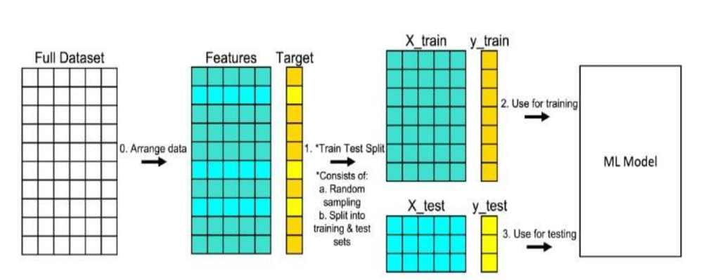

Random State: It controls the randomness of algorithms that depend on random processes (like splitting data into training and test sets, initializing weights in models, etc.).

Seed (42): The number 42 is arbitrary; it can be any integer. By setting the random_state to a specific number (e.g., 42), the random number generator will produce the same sequence of numbers every time, ensuring that the results are consistent across multiple runs.

```python
X_train, X_test, y_train, y_test = train_test_split(X, y, test_size=0.2, random_state=42) # 'test_size=0.2' means 20% of the data will be used for testing, while 80% will be used for training
```

### Check the shape of all of these

```python
print("X_train shape is : ", X_train.shape)
print("X_test shape  is : ", X_test.shape)
print("y_train shape is : ", y_train.shape)
print("y_test shape is  : ", y_test.shape)
```

```
X_train shape is :  (712, 8)
X_test shape  is :  (179, 8)
y_train shape is :  (712,)
y_test shape is  :  (179,)
```

# ML Training

A machine learning (ML) model is an algorithm that learns patterns from data to make predictions or decisions without explicit programming for specific tasks. By training on data, an ML model can generalize to new, unseen data, enabling applications like classification, regression, and clustering in various domains.

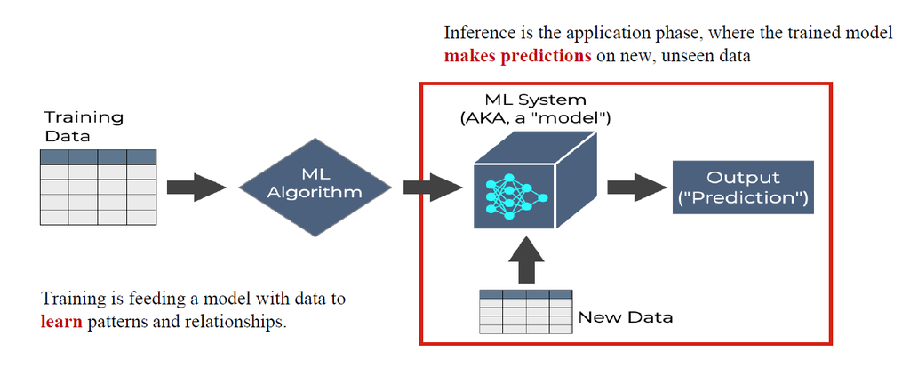

## Decision Tree model

[figure not shown]

### Train Decision Tree Classifier

```python
# Initialize a Decision Tree Classifier with a set random state for reproducibility
decision_tree = DecisionTreeClassifier(random_state=42)

# Train (fit) the Decision Tree model on the training data
decision_tree.fit(X_train, y_train)
```

```
DecisionTreeClassifier(random_state=42)
```

### Predictions with the Decision Tree model

```python
y_pred = decision_tree.predict(X_test)  # Use the trained Decision Tree model to make predictions on the test data
y_pred
```

```
array([0., 1., 0., 1., 1., 1., 1., 0., 1., 1., 0., 0., 0., 0., 0., 1., 0.,
       1., 0., 0., 0., 0., 0., 0., 0., 0., 0., 1., 0., 0., 0., 1., 1., 1.,
       0., 0., 1., 1., 1., 0., 0., 1., 0., 0., 1., 0., 0., 0., 1., 0., 1.,
       1., 0., 1., 1., 1., 1., 0., 1., 0., 1., 1., 1., 0., 0., 1., 0., 0.,
       0., 1., 1., 1., 1., 1., 0., 0., 1., 1., 1., 1., 0., 1., 1., 0., 0.,
       0., 1., 1., 0., 0., 1., 0., 0., 0., 0., 0., 1., 0., 1., 0., 0., 0.,
       1., 0., 0., 1., 1., 0., 1., 1., 1., 0., 1., 1., 0., 0., 0., 0., 1.,
       0., 0., 1., 1., 1., 0., 0., 1., 1., 0., 0., 1., 0., 0., 1., 1., 0.,
       1., 0., 0., 1., 0., 1., 1., 0., 0., 1., 0., 1., 1., 0., 0., 1., 0.,
       0., 0., 0., 0., 1., 1., 1., 0., 0., 0., 1., 0., 0., 0., 1., 0., 0.,
       0., 0., 1., 0., 0., 0., 0., 1., 1.])
```

### Convert the y_test Series to a NumPy array for easier handling in calculations or comparisons

```python
y_test_array = np.array(y_test)
y_test_array  # Display the array to confirm the conversion
```

```
array([1., 0., 0., 1., 1., 1., 1., 0., 1., 1., 0., 0., 0., 0., 0., 1., 1.,
       1., 0., 0., 0., 1., 1., 0., 0., 0., 0., 1., 0., 0., 0., 1., 0., 0.,
       1., 0., 1., 1., 1., 0., 0., 0., 0., 0., 0., 0., 0., 0., 0., 0., 1.,
       1., 0., 1., 0., 1., 0., 1., 1., 1., 0., 1., 1., 0., 0., 0., 0., 0.,
       0., 1., 0., 1., 1., 1., 0., 0., 0., 1., 0., 0., 0., 1., 1., 0., 0.,
       0., 1., 1., 0., 0., 1., 0., 0., 0., 0., 0., 1., 1., 1., 0., 0., 0.,
       1., 0., 0., 0., 1., 0., 1., 1., 1., 0., 1., 1., 0., 0., 0., 0., 1.,
       0., 0., 1., 1., 1., 0., 1., 1., 0., 0., 0., 1., 1., 0., 1., 1., 1.,
       1., 0., 0., 0., 0., 0., 0., 0., 0., 1., 0., 0., 1., 0., 0., 0., 0.,
       1., 0., 0., 1., 1., 1., 0., 0., 1., 0., 1., 0., 0., 0., 1., 0., 0.,
       1., 1., 1., 0., 0., 0., 1., 1., 1.])
```

### Create a DataFrame to compare actual and predicted values side by side

```python
comparison_df = pd.DataFrame({
    'Actual': y_test,    # Actual values from y_test
    'Predicted': y_pred  # Predicted values from y_pred
})

comparison_df            # Display the first few rows of the comparison table
```

|  | Actual | Predicted |
| --- | --- | --- |
| 709 | 1.0 | 0.0 |
| 439 | 0.0 | 1.0 |
| 840 | 0.0 | 0.0 |
| 720 | 1.0 | 1.0 |
| 39 | 1.0 | 1.0 |
| ... | ... | ... |
| 433 | 0.0 | 0.0 |
| 773 | 0.0 | 0.0 |
| 25 | 1.0 | 0.0 |
| 84 | 1.0 | 1.0 |
| 10 | 1.0 | 1.0 |

179 rows × 2 columns

### Calculate the number of matching and mismatching predictions

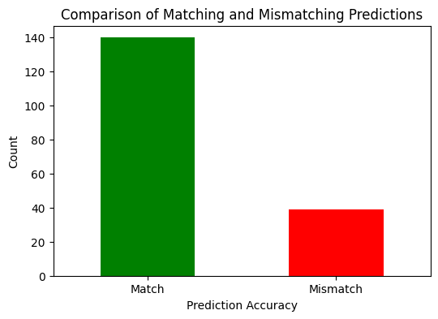

```python
comparison_df['Match'] = comparison_df['Actual'] == comparison_df['Predicted']
match_counts = comparison_df['Match'].value_counts()

# Plotting the counts of matching and mismatching predictions
plt.figure(figsize=(6, 4))
match_counts.plot(kind='bar', color=['green', 'red'], rot=0)
plt.title('Comparison of Matching and Mismatching Predictions')
plt.xlabel('Prediction Accuracy')
plt.ylabel('Count')
plt.xticks(ticks=[0, 1], labels=['Match', 'Mismatch'], rotation=0)
plt.show()
```

### Calculate the the model's predictions result

```python
accuracy = accuracy_score(y_test, y_pred)
classification_rep = classification_report(y_test, y_pred) # Generate a detailed classification report to evaluate precision, recall, and F1-score

# Print the accuracy and classification report
print("Accuracy:", accuracy)
print("Classification Report:\n", classification_rep)
```

```
Accuracy: 0.7821229050279329
Classification Report:
               precision    recall  f1-score   support

         0.0       0.83      0.79      0.81       105
         1.0       0.72      0.77      0.75        74

    accuracy                           0.78       179
   macro avg       0.78      0.78      0.78       179
weighted avg       0.79      0.78      0.78       179
```

### Display a confusion matrix to visualize the classification performance

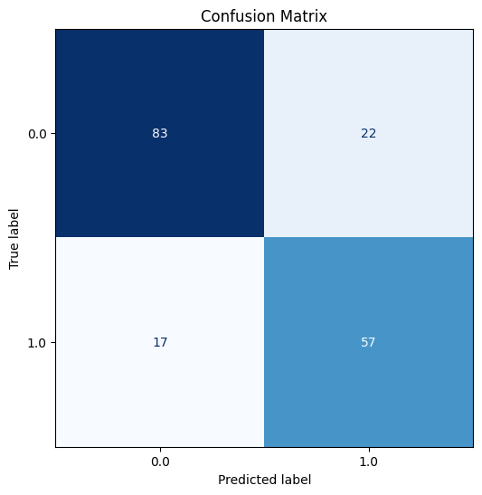

```python
# Display a confusion matrix to visualize the classification performance
fig, ax = plt.subplots(figsize=(8, 6))
ConfusionMatrixDisplay.from_predictions(y_test, y_pred, ax=ax, cmap="Blues", colorbar=False)
plt.title("Confusion Matrix")
```

### Check model performance with random data

```python
# Define the input data with all features, including 'FamilySize'
input_data = {
    'Pclass': 1,
    'Sex': 0,
    'Age': 25,
    'SibSp': 0,
    'Parch': 0,
    'Fare': 7.25,
    'Embarked': 2
}

# Calculate 'FamilySize' based on 'SibSp' and 'Parch'
input_data['FamilySize'] = input_data['SibSp'] + input_data['Parch'] + 1

# Convert the input dictionary into a DataFrame
input_df = pd.DataFrame([input_data])

# Make the prediction
prediction = decision_tree.predict(input_df)

# Print the result
print("Prediction:", "Survived" if prediction[0] == 1 else "Did not survive")
```

```
Prediction: Did not survive
```

## RandomForest Classifier

[figure not shown]

### Train Random Forest

```python
random_forest = RandomForestClassifier(n_estimators=100) # Initialize the Random Forest classifier with 100 decision trees
random_forest.fit(X_train, y_train)                      # Train (fit) the Random Forest model on the training data
```

```
RandomForestClassifier()
```

### Predictions with the Random Forest

```python
y_pred_rf = random_forest.predict(X_test)
```

### Calculate the the model's predictions result

```python
accuracy_rf = accuracy_score(y_test, y_pred_rf)
classification_rep_rf = classification_report(y_test, y_pred_rf)

print(f"Random Forest Accuracy: {accuracy_rf}")
print(f"Classification Report:\n{classification_rep_rf}")
```

```
Random Forest Accuracy: 0.8268156424581006
Classification Report:
              precision    recall  f1-score   support

         0.0       0.85      0.86      0.85       105
         1.0       0.79      0.78      0.79        74

    accuracy                           0.83       179
   macro avg       0.82      0.82      0.82       179
weighted avg       0.83      0.83      0.83       179
```

## Support Vector Classifier

[figure not shown]

### Train SVC

```python
svm_model = SVC(kernel='linear')
svm_model.fit(X_train, y_train)
```

```
SVC(kernel='linear')
```

```python
y_pred_svm = svm_model.predict(X_test)
```

### Calculate the the model's predictions result

```python
accuracy_svm = accuracy_score(y_test, y_pred_svm)
classification_rep_svm = classification_report(y_test, y_pred_svm)

print(f"SVM Accuracy: {accuracy_svm}")
print(f"Classification Report:\n{classification_rep_svm}")
```

```
SVM Accuracy: 0.7821229050279329
Classification Report:
              precision    recall  f1-score   support

         0.0       0.80      0.84      0.82       105
         1.0       0.75      0.70      0.73        74

    accuracy                           0.78       179
   macro avg       0.78      0.77      0.77       179
weighted avg       0.78      0.78      0.78       179
```

## GaussianNB

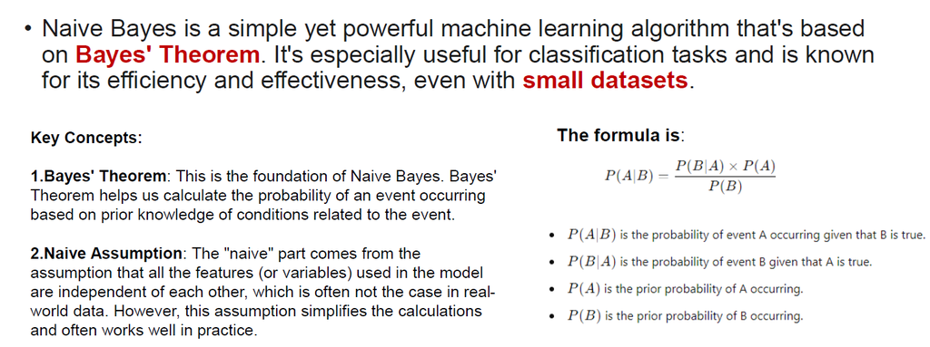

### Train GaussianNB

```python
nb_model = GaussianNB()
nb_model.fit(X_train, y_train)
```

```
GaussianNB()
```

### Predictions with the GaussianNB

```python
y_pred_nb = nb_model.predict(X_test)
```

### Calculate the the model's predictions result

```python
accuracy_nb = accuracy_score(y_test, y_pred_nb)
classification_rep_nb = classification_report(y_test, y_pred_nb)

print(f"Naive Bayes Accuracy: {accuracy_nb}")
print(f"Classification Report:\n{classification_rep_nb}")
```

```
Naive Bayes Accuracy: 0.7821229050279329
Classification Report:
              precision    recall  f1-score   support

         0.0       0.83      0.79      0.81       105
         1.0       0.72      0.77      0.75        74

    accuracy                           0.78       179
   macro avg       0.78      0.78      0.78       179
weighted avg       0.79      0.78      0.78       179
```

## K-Neighbors Classifier

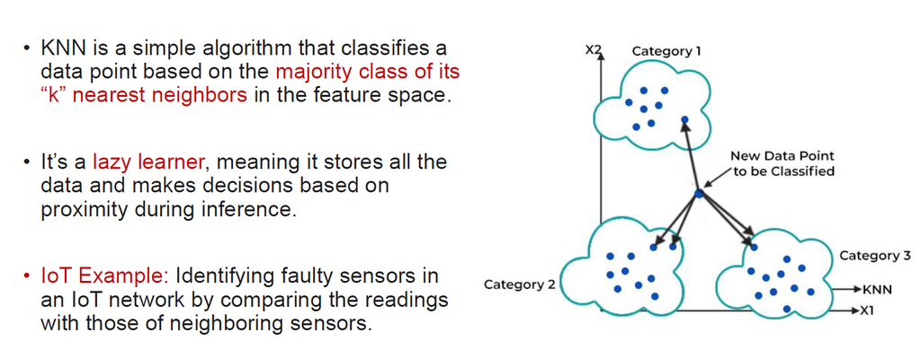

### Train KNeighborsClassifier

```python
knn_model = KNeighborsClassifier(n_neighbors=5)
knn_model.fit(X_train, y_train)
```

```
KNeighborsClassifier()
```

### Predictions with the KNeighborsClassifier

```python
y_pred_knn = knn_model.predict(X_test)
```

### Calculate the the model's predictions result

```python
accuracy_knn = accuracy_score(y_test, y_pred_knn)
classification_rep_knn = classification_report(y_test, y_pred_knn)

print(f"KNN Accuracy: {accuracy_knn}")
print(f"Classification Report:\n{classification_rep_knn}")
```

```
KNN Accuracy: 0.8212290502793296
Classification Report:
              precision    recall  f1-score   support

         0.0       0.83      0.88      0.85       105
         1.0       0.81      0.74      0.77        74

    accuracy                           0.82       179
   macro avg       0.82      0.81      0.81       179
weighted avg       0.82      0.82      0.82       179
```

## Comparison of Model Accuracy Scores

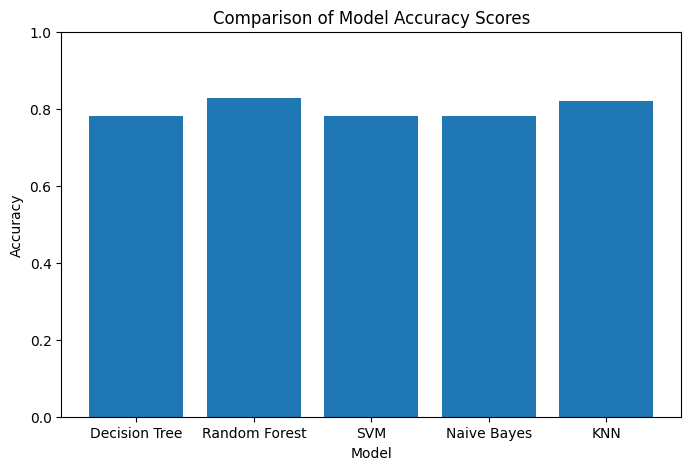

```python
# Calculate accuracy scores for each model
accuracy_scores = {
    "Decision Tree": accuracy_score(y_test, y_pred),
    "Random Forest": accuracy_score(y_test, y_pred_rf),
    "SVM": accuracy_score(y_test, y_pred_svm),
    "Naive Bayes": accuracy_score(y_test, y_pred_nb),
    "KNN": accuracy_score(y_test, y_pred_knn)
}

# Plotting accuracy scores in a bar chart
plt.figure(figsize=(8, 5))
plt.bar(accuracy_scores.keys(), accuracy_scores.values())
plt.ylim(0, 1)
plt.title("Comparison of Model Accuracy Scores")
plt.xlabel("Model")
plt.ylabel("Accuracy")
plt.show()
```

## Compare all the model results

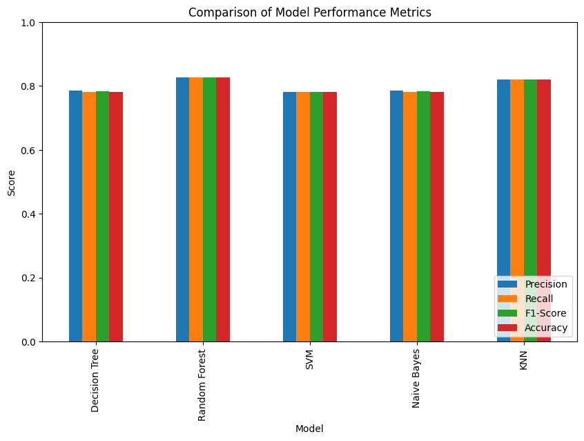

```python
metrics = {
    "Decision Tree": classification_report(y_test, y_pred, output_dict=True)["weighted avg"],
    "Random Forest": classification_report(y_test, y_pred_rf, output_dict=True)["weighted avg"],
    "SVM": classification_report(y_test, y_pred_svm, output_dict=True)["weighted avg"],
    "Naive Bayes": classification_report(y_test, y_pred_nb, output_dict=True)["weighted avg"],
    "KNN": classification_report(y_test, y_pred_knn, output_dict=True)["weighted avg"]
}

# Extracting precision, recall, and f1-score for each model
metrics_df = pd.DataFrame({
    "Precision": {model: metrics[model]["precision"] for model in metrics},
    "Recall": {model: metrics[model]["recall"] for model in metrics},
    "F1-Score": {model: metrics[model]["f1-score"] for model in metrics},
    "Accuracy": {model: accuracy_scores[model] for model in accuracy_scores}
})

# Plotting all metrics for each model in a grouped bar chart
metrics_df.plot(kind="bar", figsize=(10, 6))
plt.ylim(0, 1)
plt.title("Comparison of Model Performance Metrics")
plt.xlabel("Model")
plt.ylabel("Score")
plt.legend(loc="lower right")
plt.show()
```

### Display the DataFrame

```python
metrics_df
```

|  | Precision | Recall | F1-Score | Accuracy |
| --- | --- | --- | --- | --- |
| Decision Tree | 0.785153 | 0.782123 | 0.783026 | 0.782123 |
| Random Forest | 0.826511 | 0.826816 | 0.826637 | 0.826816 |
| SVM | 0.780827 | 0.782123 | 0.780847 | 0.782123 |
| Naive Bayes | 0.785153 | 0.782123 | 0.783026 | 0.782123 |
| KNN | 0.820558 | 0.821229 | 0.819935 | 0.821229 |

The Random Forest model is the top choice due to its consistently high performance across metrics, making it the most effective and reliable classifier for this dataset. KNN also performs well, particularly where a simpler model is preferred. However, Decision Tree, Naive Bayes, and SVM provide reasonable performance but may require additional tuning or feature engineering to match the Random Forest’s accuracy and robustness.